# Genetic Dependency Detection

Martin Brand

April 6, 2023

We import the libraries.

```r
library(tidyverse)
library(ggplot2)
library(ggrepel)
library(matrixTests)
library(dplyr)
library(cowplot)
library(limma)
library(gridExtra)
```

# Analyzed Genes and Target

We define the genes for classification, the expected target gene and the classification criteria.

```r
gene1 <- "NRAS"
gene2 <- "NRAS"
# target.genes <- c("FUBP1","SF1","U2AF1","U2AF2","SNRPB","SNRPD1","SNRPD2",
#                   "SNRPD3","SNRPE","SNRPF","SNRPG","PUF60","SMNDC1",
#                   "DNAJC8","RBM17","CHERP","U2SURP","DHX15","DDX46","CELF6",
#                   "PCBP1")
# target.genes <- c("PARP1","PARP2")
target.genes <- c("NRAS","SHOC2")
# possible methods: "del.vs.non.del", "del.vs.non.mut","mut.vs.non.mut"
classification.method <- "mut.vs.non.mut"
```

In this analysis, the genes used for classification are NRAS and NRAS. The expected target gene is NRAS, SHOC2.

# Data Preprocessing

We define the directory for the data and helper functions.

```r
data.dir <-
  "C:/Users/Martin/Documents/Master/Thesis/genetic_dependency_detection/data/"
```

We load the dataset that contains CCLE IDs and corresponding DepMap IDs for the cell lines ([DepMapIDs](https://depmap.org/portal/download/all/?releasename=DepMap+Public+18Q3&filename=DepMap-2018q3-celllines.csv)), the dataset that contains the mutation information of the cell lines ([CCLE dataset](https://depmap.org/portal/download/all/?releasename=DepMap+Public+19Q2&filename=CCLE_mutations.csv)) and the datasets that contains the dependency scores from the projects Achilles and DRIVE ([DepMap datasets](https://figshare.com/articles/dataset/DepMap_Datasets_for_WRN_manuscript/7712756/1)).

```r
cancer.names <- read.csv(paste0(data.dir, "DepMap-2018q3-celllines.csv"))
cancer.names <- cancer.names[,c(1,2)]
colnames(cancer.names) <- c("DepMap_ID","CCLE_ID")

CCLE.mut <- read.csv(paste0(data.dir, "CCLE_mutations.csv"))
CCLE.mut <- CCLE.mut[,c(1,8,16,20)]

dep.scores <- read_rds(file.path(data.dir, 'DepMap_18Q4_data.rds'))

dep.scores.DRIVE <- as.data.frame(dep.scores[["DRIVE"]])
dep.scores.DRIVE$CCLE_ID <- rownames(dep.scores.DRIVE)
rownames(dep.scores.DRIVE) <- NULL
dep.scores.DRIVE <- dep.scores.DRIVE %>% select(CCLE_ID, everything())

dep.scores.Achilles <- as.data.frame(dep.scores[["CRISPR"]])
dep.scores.Achilles$CCLE_ID <- rownames(dep.scores.Achilles)
rownames(dep.scores.Achilles) <- NULL
dep.scores.Achilles <- dep.scores.Achilles %>% select(CCLE_ID,everything())

# remove unnecessary objects
rm(dep.scores)

# save important objects
saveRDS(cancer.names,paste0(data.dir,"cancer.names.rds"))
saveRDS(CCLE.mut,paste0(data.dir,"CCLE.mut.rds"))
saveRDS(dep.scores.DRIVE,paste0(data.dir,"dep.scores.DRIVE.rds"))
saveRDS(dep.scores.Achilles,paste0(data.dir,"dep.scores.Achilles.rds"))
```

```r
# load important objects
cancer.names <- readRDS(paste0(data.dir,"cancer.names.rds"))
CCLE.mut <- readRDS(paste0(data.dir,"CCLE.mut.rds"))
dep.scores.DRIVE <- readRDS(paste0(data.dir,"dep.scores.DRIVE.rds"))
dep.scores.Achilles <- readRDS(paste0(data.dir,"dep.scores.Achilles.rds"))
```

We load the helper functions.

```r
# load helper functions
source("helper_functions/create.mutation.counts.plot.R")
source("helper_functions/create.mutation.counts.plot.mark.R")
source("helper_functions/create.classification.table.del.vs.non.del.R")
source("helper_functions/create.classification.table.mut.vs.non.mut.R")
source("helper_functions/create.classification.table.del.vs.non.mut.R")
source("helper_functions/merge.class.tables.R")
source("helper_functions/merge.class.tables.AND.R")
source("helper_functions/create_barcharts_classifications.R")
source("helper_functions/plot.mean.diffs.R")
source("helper_functions/calc.mean.diffs.and.p.values.R")
source("helper_functions/create_volcano_plot.R")
source("helper_functions/create.significant.genes.table.R")
```

# Data Exploration

## Mutation Counts

To find potential genes for classification, we plot the distribution of mutation numbers in the overlapping genes of the CCLE dataset and the datasets DRIVE and Achilles.

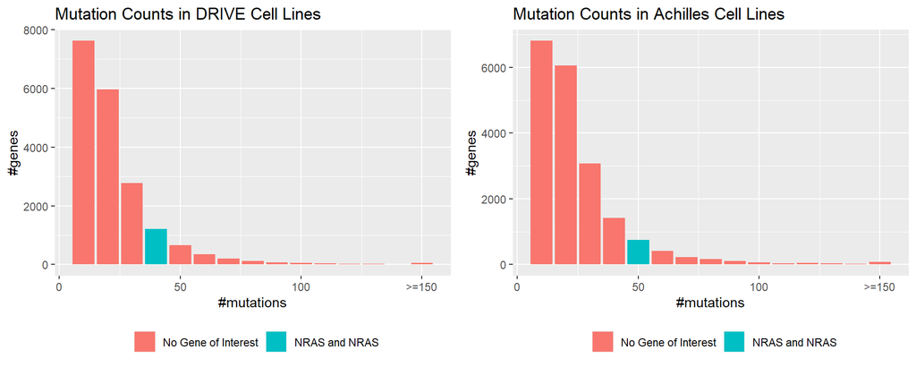

```r
mutation.plot.DRIVE <- create.mutation.counts.plot.mark("DRIVE",dep.scores.DRIVE,
                                                   cancer.names,CCLE.mut)

mutation.plot.Achilles <- create.mutation.counts.plot.mark("Achilles",
                                                      dep.scores.Achilles,
                                                      cancer.names,CCLE.mut)

grid.arrange(mutation.plot.DRIVE,mutation.plot.Achilles,ncol=2)
```

```r
rm(mutation.plot.DRIVE,mutation.plot.Achilles)
```

## Classification Tables for NRAS and NRAS

We create classification tables that show us for each cell line whether the selected genes are deleteriously mutated or not. Therefore we create one table where we check whether NRAS is deleteriously mutated, another table where we do the same for NRAS and a third table where we check whether at least one of NRAS and NRAS is deleteriously mutated.

```r
create.classification.table <- switch(classification.method,
                "del.vs.non.del" = create.classification.table.del.vs.non.del,
                "del.vs.non.mut" = create.classification.table.del.vs.non.mut,
                "mut.vs.non.mut" = create.classification.table.mut.vs.non.mut)

class.table.gene1 <- create.classification.table(
                                                CCLE.mut, cancer.names,
                                                gene1, dep.scores.DRIVE,
                                                dep.scores.Achilles)
class.table.gene2 <- create.classification.table(
                                                CCLE.mut, cancer.names,
                                                gene2, dep.scores.DRIVE,
                                                dep.scores.Achilles)

# merge tables
class.table.comb.DRIVE <- merge.class.tables(class.table.gene1$DRIVE,
                                             class.table.gene2$DRIVE)

class.table.comb.Achilles <- merge.class.tables(class.table.gene1$Achilles,
                                             class.table.gene2$Achilles)

knitr::kable(head(class.table.comb.DRIVE), format = "html",
             table.attr = "style='width:50%;'",
             caption = "Significant Genes in DRIVE")
```

| CCLE_ID | isDeleterious |
| --- | --- |
| 127399_SOFT_TISSUE | FALSE |
| 1321N1_CENTRAL_NERVOUS_SYSTEM | FALSE |
| 2313287_STOMACH | FALSE |
| 697_HAEMATOPOIETIC_AND_LYMPHOID_TISSUE | TRUE |
| 769P_KIDNEY | FALSE |
| 786O_KIDNEY | FALSE |

```r
rm(CCLE.mut,cancer.names)
```

## Classifications for NRAS

To check whether the samples sizes regarding NRAS for the following statistical tests are sufficient, we plot the number of cell lines for both samples.

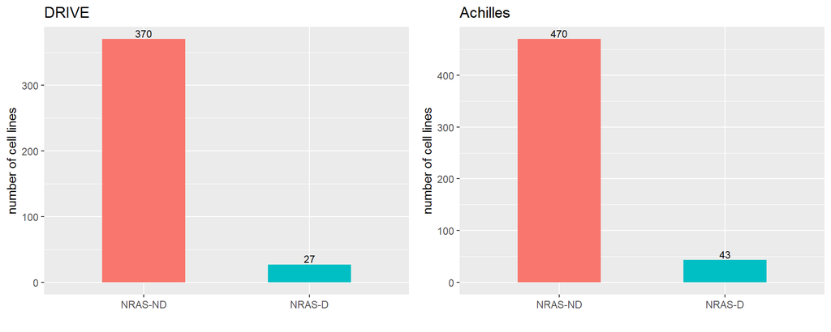

```r
barcharts.gene1 <- create_barcharts_classifications(class.table.gene1$DRIVE,
                                              class.table.gene1$Achilles,
                                              gene1)
plot_grid(barcharts.gene1$DRIVE, barcharts.gene1$Achilles)
```

```r
rm(barcharts.gene1)
```

## Classifications for NRAS

We repeat the plots for NRAS.

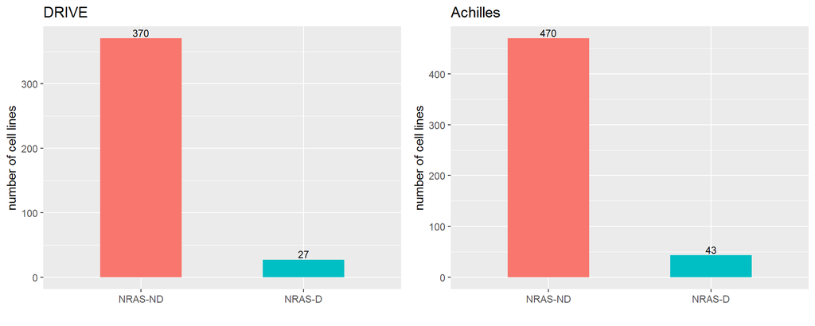

```r
barcharts.gene2 <- create_barcharts_classifications(class.table.gene2$DRIVE,
                                              class.table.gene2$Achilles,
                                              gene2)
plot_grid(barcharts.gene2$DRIVE, barcharts.gene2$Achilles)
```

```r
rm(barcharts.gene2)
```

## Classifications for NRASand NRAS

We repeat the plots for NRASand NRAS.

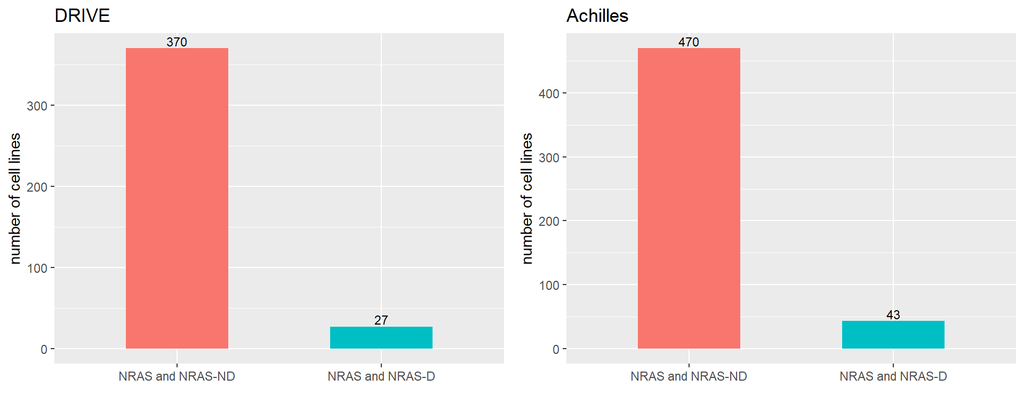

```r
barcharts.comb.genes <- create_barcharts_classifications(class.table.comb.DRIVE,
                                              class.table.comb.Achilles,
                                              paste(gene1,"and",gene2))
plot_grid(barcharts.comb.genes$DRIVE, barcharts.comb.genes$Achilles)
```

```r
rm(barcharts.comb.genes)
```

# Data Analysis NRAS

In order to detect differences between both samples, we compare them for each gene in the datasets DRIVE and Achilles. The workflow was published by [Chan et al., 2019](https://www.nature.com/articles/s41586-019-1102-x).

## Mean Differences

To test whether the two groups respond differently to the knock out or the knock down of a specific gene, we calculate the mean differences between the two groups for each gene.

```r
test.results.gene1 <- calc.mean.diffs.and.p.values(dep.scores.DRIVE,
                                           dep.scores.Achilles,
                                           class.table.gene1$DRIVE,
                                           class.table.gene1$Achilles)

plots <- plot.mean.diffs(test.results.gene1)
grid.arrange(plots$DRIVE,plots$Achilles,ncol=2)
```

[output not shown]

```r
rm(class.table.gene1,plots)
```

## Welch Test

The Welch t-test checks whether the means of two samples are identical. The prerequisite is that both samples are normally distributed, which we have not yet ensured.

```r
plot.welch.DRIVE.gene1 <- create_volcano_plot(test.results.gene1,"DRIVE",
                                              "welch",target.genes,
                                              show_sign_line=T)

plot.welch.Achilles.gene1 <- create_volcano_plot(test.results.gene1,"Achilles",
                                                "welch",target.genes)

grid.arrange(plot.welch.DRIVE.gene1,plot.welch.Achilles.gene1,ncol=2)
```

[output not shown]

```r
rm(plot.welch.DRIVE.gene1,plot.welch.Achilles.gene1)
```

To discover new potential dependencies, the table shows all significant genes.

```r
significant.genes.table.DRIVE.gene1 <- create.significant.genes.table(
  test.results.gene1,"DRIVE","welch")
significant.genes.table.Achilles.gene1 <- create.significant.genes.table(
  test.results.gene1,"Achilles","welch")

knitr::kable(significant.genes.table.DRIVE.gene1, format = "html",
             table.attr = "style='width:50%;'",
             caption = "Significant Genes in DRIVE")
```

Table 2: Significant Genes in DRIVE

|  | gene | p_value | p_adj | log |
| --- | --- | --- | --- | --- |
| 632 | TMED10 | 1.20e-06 | 0.0039627 | 5.530820 |
| 4194 | NRAS | 6.00e-07 | 0.0039627 | 5.530820 |
| 4513 | GHRL | 2.00e-06 | 0.0039627 | 5.530820 |
| 6196 | HNF1B | 1.80e-06 | 0.0039627 | 5.530820 |
| 2184 | ARHGEF18 | 1.67e-05 | 0.0266197 | 3.626103 |
| 2362 | MCM9 | 2.55e-05 | 0.0338384 | 3.386160 |

```r
knitr::kable(significant.genes.table.Achilles.gene1, format = "html",
             table.attr = "style='width:50%;'",
             caption = "Significant Genes in Achilles")
```

Table 2: Significant Genes in Achilles

|  | gene | p_value | p_adj | log |
| --- | --- | --- | --- | --- |
| 10065 | NRAS | 0.00e+00 | 0.0000000 | 22.554870 |
| 6240 | GRB2 | 0.00e+00 | 0.0000049 | 12.226599 |
| 12166 | PTPN11 | 1.00e-07 | 0.0006149 | 7.394024 |
| 12388 | RAF1 | 4.00e-07 | 0.0018500 | 6.292584 |
| 13625 | SHOC2 | 6.00e-07 | 0.0020807 | 6.175027 |
| 5660 | GAB1 | 2.20e-06 | 0.0064591 | 5.042263 |
| 7858 | KRAS | 6.80e-06 | 0.0150594 | 4.195753 |
| 11783 | PPP4C | 6.50e-06 | 0.0150594 | 4.195753 |
| 9114 | MORF4L1 | 9.20e-06 | 0.0180136 | 4.016630 |
| 6058 | GOLGA7 | 1.15e-05 | 0.0202926 | 3.897498 |
| 4522 | EGFR | 1.31e-05 | 0.0209437 | 3.865920 |
| 5669 | GABPB1 | 3.03e-05 | 0.0445709 | 3.110673 |

```r
rm(significant.genes.table.DRIVE.gene1,significant.genes.table.Achilles.gene1)
```

## Wilcoxon Test

The Wilcoxon test checks whether, for randomly selected values X and Y from two samples, the probability of X being greater than Y is equal to the probability of Y being greater than X. The prerequisite is that the data are ordinary, which is fulfilled here.

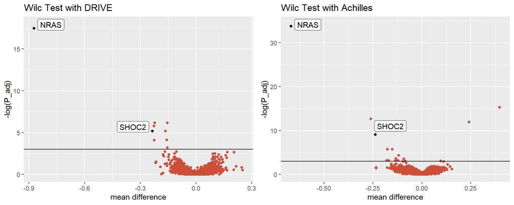

```r
plot.wilc.DRIVE.gene1 <- create_volcano_plot(test.results.gene1,"DRIVE","wilc",
                                       target.genes, show_sign_line=T)

plot.wilc.Achilles.gene1 <- create_volcano_plot(test.results.gene1,"Achilles",
                                                "wilc",target.genes)

grid.arrange(plot.wilc.DRIVE.gene1,plot.wilc.Achilles.gene1,ncol=2)
```

```r
rm(plot.wilc.DRIVE.gene1,plot.wilc.Achilles.gene1)
```

```r
significant.genes.table.DRIVE.gene1 <- create.significant.genes.table(
  test.results.gene1,"DRIVE","wilc")
significant.genes.table.Achilles.gene1 <- create.significant.genes.table(
  test.results.gene1,"Achilles","wilc")

knitr::kable(significant.genes.table.DRIVE.gene1, format = "html",
             table.attr = "style='width:50%;'",
             caption = "Significant Genes in DRIVE")
```

Table 3: Significant Genes in DRIVE

|  | gene | p_value | p_adj | log |
| --- | --- | --- | --- | --- |
| 4194 | NRAS | 0.00e+00 | 0.0000000 | 17.474261 |
| 4513 | GHRL | 5.00e-07 | 0.0021114 | 6.160415 |
| 2184 | ARHGEF18 | 8.00e-07 | 0.0021201 | 6.156271 |
| 2362 | MCM9 | 1.50e-06 | 0.0030402 | 5.795824 |
| 6795 | SHOC2 | 4.00e-06 | 0.0056484 | 5.176391 |
| 6857 | TSSK3 | 4.20e-06 | 0.0056484 | 5.176391 |
| 3535 | ANKRD36 | 1.44e-05 | 0.0164305 | 4.108618 |
| 541 | LOC107984065 | 1.70e-05 | 0.0169285 | 4.078757 |
| 4731 | ING3 | 4.54e-05 | 0.0402617 | 3.212355 |

```r
knitr::kable(significant.genes.table.Achilles.gene1, format = "html",
             table.attr = "style='width:50%;'",
             caption = "Significant Genes in Achilles")
```

Table 3: Significant Genes in Achilles

|  | gene | p_value | p_adj | log |
| --- | --- | --- | --- | --- |
| 10065 | NRAS | 0.00e+00 | 0.0000000 | 33.764759 |
| 6240 | GRB2 | 0.00e+00 | 0.0000002 | 15.287694 |
| 12388 | RAF1 | 0.00e+00 | 0.0000031 | 12.690801 |
| 12166 | PTPN11 | 0.00e+00 | 0.0000067 | 11.911625 |
| 13625 | SHOC2 | 0.00e+00 | 0.0001169 | 9.053978 |
| 6058 | GOLGA7 | 1.20e-06 | 0.0031609 | 5.756905 |
| 9114 | MORF4L1 | 1.30e-06 | 0.0031609 | 5.756905 |
| 2907 | CHCHD3 | 6.00e-06 | 0.0132185 | 4.326141 |
| 5669 | GABPB1 | 1.37e-05 | 0.0269077 | 3.615343 |
| 7088 | IKZF1 | 1.67e-05 | 0.0294338 | 3.525613 |
| 3309 | COLCA2 | 3.11e-05 | 0.0408475 | 3.197910 |
| 8838 | MED24 | 3.17e-05 | 0.0408475 | 3.197910 |
| 9168 | MRGBP | 3.24e-05 | 0.0408475 | 3.197910 |
| 11783 | PPP4C | 2.67e-05 | 0.0408475 | 3.197910 |
| 1279 | BAHD1 | 4.29e-05 | 0.0472954 | 3.051343 |
| 10880 | PARVA | 4.29e-05 | 0.0472954 | 3.051343 |

```r
rm(significant.genes.table.DRIVE.gene1,significant.genes.table.Achilles.gene1)
```

## Bayes Test

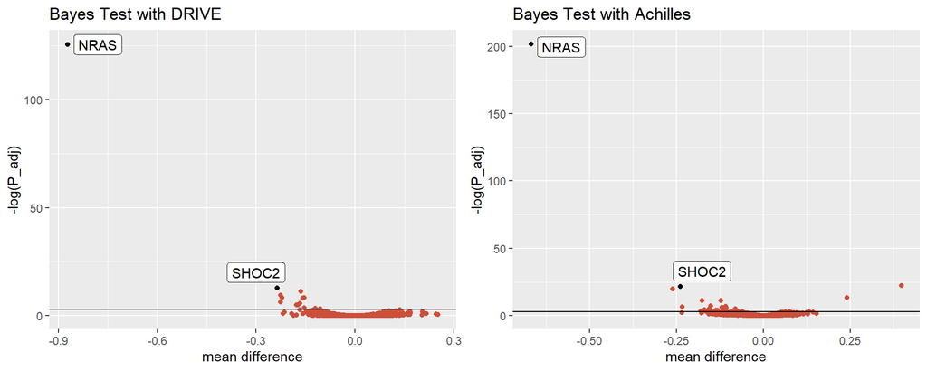

```r
plot.bayes.DRIVE.gene1 <- create_volcano_plot(test.results.gene1,"DRIVE","bayes",
                                       target.genes)

plot.bayes.Achilles.gene1 <- create_volcano_plot(test.results.gene1,"Achilles",
                                                "bayes",target.genes)

grid.arrange(plot.bayes.DRIVE.gene1,plot.bayes.Achilles.gene1,ncol=2)
```

```r
rm(plot.bayes.DRIVE.gene1,plot.bayes.Achilles.gene1)
```

```r
significant.genes.table.DRIVE.gene1 <- create.significant.genes.table(
  test.results.gene1,"DRIVE","bayes")
significant.genes.table.Achilles.gene1 <- create.significant.genes.table(
  test.results.gene1,"Achilles","bayes")

knitr::kable(significant.genes.table.DRIVE.gene1, format = "html",
             table.attr = "style='width:50%;'",
             caption = "Significant Genes in DRIVE")
```

Table 4: Significant Genes in DRIVE

|  | gene | p_adj | log |
| --- | --- | --- | --- |
| 4194 | NRAS | 0.0000000 | 125.427242 |
| 6795 | SHOC2 | 0.0000029 | 12.746940 |
| 6857 | TSSK3 | 0.0000147 | 11.127930 |
| 2362 | MCM9 | 0.0000859 | 9.361909 |
| 2184 | ARHGEF18 | 0.0002287 | 8.383156 |
| 4513 | GHRL | 0.0002287 | 8.383156 |
| 3535 | ANKRD36 | 0.0002956 | 8.126597 |
| 541 | LOC107984065 | 0.0018139 | 6.312264 |
| 5530 | RAF1 | 0.0033609 | 5.695554 |
| 2804 | UTS2R | 0.0064286 | 5.046997 |
| 4319 | SOST | 0.0068349 | 4.985715 |
| 4731 | ING3 | 0.0237142 | 3.741682 |
| 1985 | ANKRD26 | 0.0324463 | 3.428170 |
| 6084 | SPG7 | 0.0398350 | 3.223009 |

```r
knitr::kable(significant.genes.table.Achilles.gene1, format = "html",
             table.attr = "style='width:50%;'",
             caption = "Significant Genes in Achilles")
```

Table 4: Significant Genes in Achilles

|  | gene | p_adj | log |
| --- | --- | --- | --- |
| 10065 | NRAS | 0.0000000 | 201.568058 |
| 6240 | GRB2 | 0.0000000 | 22.316905 |
| 13625 | SHOC2 | 0.0000000 | 21.466882 |
| 12388 | RAF1 | 0.0000000 | 19.845255 |
| 12166 | PTPN11 | 0.0000017 | 13.264172 |
| 3309 | COLCA2 | 0.0000122 | 11.315815 |
| 6058 | GOLGA7 | 0.0000122 | 11.315815 |
| 9114 | MORF4L1 | 0.0007926 | 7.140169 |
| 4150 | DMXL1 | 0.0010785 | 6.832141 |
| 7293 | IRF4 | 0.0015318 | 6.481309 |
| 2907 | CHCHD3 | 0.0018524 | 6.291247 |
| 12558 | RCE1 | 0.0025158 | 5.985163 |
| 3187 | CNBP | 0.0045644 | 5.389479 |
| 6308 | GSS | 0.0052523 | 5.249087 |
| 6503 | HECTD2 | 0.0063393 | 5.060987 |
| 8256 | LIPT1 | 0.0063940 | 5.052390 |
| 9168 | MRGBP | 0.0121296 | 4.412107 |
| 11783 | PPP4C | 0.0174606 | 4.047810 |
| 5669 | GABPB1 | 0.0195888 | 3.932796 |
| 1279 | BAHD1 | 0.0212943 | 3.849314 |
| 8838 | MED24 | 0.0323662 | 3.430641 |
| 12351 | RABGEF1 | 0.0323662 | 3.430641 |
| 1126 | ATP1B3 | 0.0324632 | 3.427650 |
| 1391 | BHMT | 0.0324632 | 3.427650 |
| 9801 | NFKB1 | 0.0324632 | 3.427650 |
| 12704 | RHEB | 0.0324632 | 3.427650 |
| 12581 | REC114 | 0.0373905 | 3.286339 |
| 4643 | EMC6 | 0.0444448 | 3.113507 |
| 13655 | SIK3 | 0.0444448 | 3.113507 |
| 6016 | GNB5 | 0.0451275 | 3.098263 |
| 1416 | BLOC1S3 | 0.0480424 | 3.035672 |
| 13775 | SLC20A1 | 0.0480424 | 3.035672 |
| 3626 | CTRB2 | 0.0495105 | 3.005571 |
| 8855 | MEF2C | 0.0499530 | 2.996672 |

```r
rm(significant.genes.table.DRIVE.gene1,significant.genes.table.Achilles.gene1,
   test.results.gene1)
```

# Data Analysis NRAS

We do the same for NRAS.

## Mean Differences

```r
test.results.gene2 <- calc.mean.diffs.and.p.values(dep.scores.DRIVE,
                                           dep.scores.Achilles,
                                           class.table.gene2$DRIVE,
                                           class.table.gene2$Achilles)

plots <- plot.mean.diffs(test.results.gene2)
grid.arrange(plots$DRIVE,plots$Achilles,ncol=2)
```

[output not shown]

```r
rm(class.table.gene2,plots)
```

## Welch Test

```r
plot.welch.DRIVE.gene2 <- create_volcano_plot(test.results.gene2,"DRIVE",
                                              "welch",target.genes,
                                              show_sign_line=T)

plot.welch.Achilles.gene2 <- create_volcano_plot(test.results.gene2,"Achilles",
                                                "welch",target.genes)

grid.arrange(plot.welch.DRIVE.gene2,plot.welch.Achilles.gene2,ncol=2)
```

[output not shown]

```r
rm(plot.welch.DRIVE.gene2,plot.welch.Achilles.gene2)
```

```r
significant.genes.table.DRIVE.gene2 <- create.significant.genes.table(
  test.results.gene2,"DRIVE","welch")
significant.genes.table.Achilles.gene2 <- create.significant.genes.table(
  test.results.gene2,"Achilles","welch")

knitr::kable(significant.genes.table.DRIVE.gene2, format = "html",
             table.attr = "style='width:50%;'",
             caption = "Significant Genes in DRIVE")
```

Table 5: Significant Genes in DRIVE

|  | gene | p_value | p_adj | log |
| --- | --- | --- | --- | --- |
| 632 | TMED10 | 1.20e-06 | 0.0039627 | 5.530820 |
| 4194 | NRAS | 6.00e-07 | 0.0039627 | 5.530820 |
| 4513 | GHRL | 2.00e-06 | 0.0039627 | 5.530820 |
| 6196 | HNF1B | 1.80e-06 | 0.0039627 | 5.530820 |
| 2184 | ARHGEF18 | 1.67e-05 | 0.0266197 | 3.626103 |
| 2362 | MCM9 | 2.55e-05 | 0.0338384 | 3.386160 |

```r
knitr::kable(significant.genes.table.Achilles.gene2, format = "html",
             table.attr = "style='width:50%;'",
             caption = "Significant Genes in Achilles")
```

Table 5: Significant Genes in Achilles

|  | gene | p_value | p_adj | log |
| --- | --- | --- | --- | --- |
| 10065 | NRAS | 0.00e+00 | 0.0000000 | 22.554870 |
| 6240 | GRB2 | 0.00e+00 | 0.0000049 | 12.226599 |
| 12166 | PTPN11 | 1.00e-07 | 0.0006149 | 7.394024 |
| 12388 | RAF1 | 4.00e-07 | 0.0018500 | 6.292584 |
| 13625 | SHOC2 | 6.00e-07 | 0.0020807 | 6.175027 |
| 5660 | GAB1 | 2.20e-06 | 0.0064591 | 5.042263 |
| 7858 | KRAS | 6.80e-06 | 0.0150594 | 4.195753 |
| 11783 | PPP4C | 6.50e-06 | 0.0150594 | 4.195753 |
| 9114 | MORF4L1 | 9.20e-06 | 0.0180136 | 4.016630 |
| 6058 | GOLGA7 | 1.15e-05 | 0.0202926 | 3.897498 |
| 4522 | EGFR | 1.31e-05 | 0.0209437 | 3.865920 |
| 5669 | GABPB1 | 3.03e-05 | 0.0445709 | 3.110673 |

```r
rm(significant.genes.table.DRIVE.gene2,significant.genes.table.Achilles.gene2)
```

## Wilcoxon Test

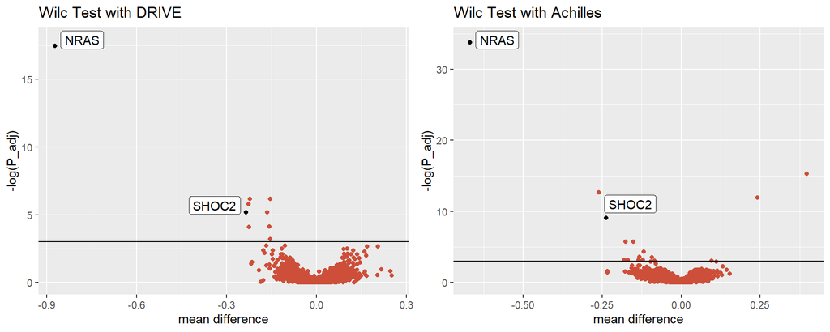

```r
plot.wilc.DRIVE.gene2 <- create_volcano_plot(test.results.gene2,"DRIVE","wilc",
                                       target.genes, show_sign_line=T)

plot.wilc.Achilles.gene2 <- create_volcano_plot(test.results.gene2,"Achilles",
                                                "wilc",target.genes)

grid.arrange(plot.wilc.DRIVE.gene2,plot.wilc.Achilles.gene2,ncol=2)
```

```r
rm(plot.wilc.DRIVE.gene2,plot.wilc.Achilles.gene2)
```

```r
significant.genes.table.DRIVE.gene2 <- create.significant.genes.table(
  test.results.gene2,"DRIVE","wilc")
significant.genes.table.Achilles.gene2 <- create.significant.genes.table(
  test.results.gene2,"Achilles","wilc")

knitr::kable(significant.genes.table.DRIVE.gene2, format = "html",
             table.attr = "style='width:50%;'",
             caption = "Significant Genes in DRIVE")
```

Table 6: Significant Genes in DRIVE

|  | gene | p_value | p_adj | log |
| --- | --- | --- | --- | --- |
| 4194 | NRAS | 0.00e+00 | 0.0000000 | 17.474261 |
| 4513 | GHRL | 5.00e-07 | 0.0021114 | 6.160415 |
| 2184 | ARHGEF18 | 8.00e-07 | 0.0021201 | 6.156271 |
| 2362 | MCM9 | 1.50e-06 | 0.0030402 | 5.795824 |
| 6795 | SHOC2 | 4.00e-06 | 0.0056484 | 5.176391 |
| 6857 | TSSK3 | 4.20e-06 | 0.0056484 | 5.176391 |
| 3535 | ANKRD36 | 1.44e-05 | 0.0164305 | 4.108618 |
| 541 | LOC107984065 | 1.70e-05 | 0.0169285 | 4.078757 |
| 4731 | ING3 | 4.54e-05 | 0.0402617 | 3.212355 |

```r
knitr::kable(significant.genes.table.Achilles.gene2, format = "html",
             table.attr = "style='width:50%;'",
             caption = "Significant Genes in Achilles")
```

Table 6: Significant Genes in Achilles

|  | gene | p_value | p_adj | log |
| --- | --- | --- | --- | --- |
| 10065 | NRAS | 0.00e+00 | 0.0000000 | 33.764759 |
| 6240 | GRB2 | 0.00e+00 | 0.0000002 | 15.287694 |
| 12388 | RAF1 | 0.00e+00 | 0.0000031 | 12.690801 |
| 12166 | PTPN11 | 0.00e+00 | 0.0000067 | 11.911625 |
| 13625 | SHOC2 | 0.00e+00 | 0.0001169 | 9.053978 |
| 6058 | GOLGA7 | 1.20e-06 | 0.0031609 | 5.756905 |
| 9114 | MORF4L1 | 1.30e-06 | 0.0031609 | 5.756905 |
| 2907 | CHCHD3 | 6.00e-06 | 0.0132185 | 4.326141 |
| 5669 | GABPB1 | 1.37e-05 | 0.0269077 | 3.615343 |
| 7088 | IKZF1 | 1.67e-05 | 0.0294338 | 3.525613 |
| 3309 | COLCA2 | 3.11e-05 | 0.0408475 | 3.197910 |
| 8838 | MED24 | 3.17e-05 | 0.0408475 | 3.197910 |
| 9168 | MRGBP | 3.24e-05 | 0.0408475 | 3.197910 |
| 11783 | PPP4C | 2.67e-05 | 0.0408475 | 3.197910 |
| 1279 | BAHD1 | 4.29e-05 | 0.0472954 | 3.051343 |
| 10880 | PARVA | 4.29e-05 | 0.0472954 | 3.051343 |

```r
rm(significant.genes.table.DRIVE.gene2,significant.genes.table.Achilles.gene2)
```

## Bayes Test

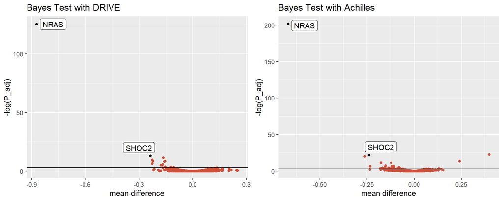

```r
plot.bayes.DRIVE.gene2 <- create_volcano_plot(test.results.gene2,"DRIVE","bayes",
                                       target.genes)

plot.bayes.Achilles.gene2 <- create_volcano_plot(test.results.gene2,"Achilles",
                                                "bayes",target.genes)

grid.arrange(plot.bayes.DRIVE.gene2,plot.bayes.Achilles.gene2,ncol=2)
```

```r
rm(plot.bayes.DRIVE.gene2,plot.bayes.Achilles.gene2)
```

```r
significant.genes.table.DRIVE.gene2 <- create.significant.genes.table(
  test.results.gene2,"DRIVE","bayes")
significant.genes.table.Achilles.gene2 <- create.significant.genes.table(
  test.results.gene2,"Achilles","bayes")

knitr::kable(significant.genes.table.DRIVE.gene2, format = "html",
             table.attr = "style='width:50%;'",
             caption = "Significant Genes in DRIVE")
```

Table 7: Significant Genes in DRIVE

|  | gene | p_adj | log |
| --- | --- | --- | --- |
| 4194 | NRAS | 0.0000000 | 125.427242 |
| 6795 | SHOC2 | 0.0000029 | 12.746940 |
| 6857 | TSSK3 | 0.0000147 | 11.127930 |
| 2362 | MCM9 | 0.0000859 | 9.361909 |
| 2184 | ARHGEF18 | 0.0002287 | 8.383156 |
| 4513 | GHRL | 0.0002287 | 8.383156 |
| 3535 | ANKRD36 | 0.0002956 | 8.126597 |
| 541 | LOC107984065 | 0.0018139 | 6.312264 |
| 5530 | RAF1 | 0.0033609 | 5.695554 |
| 2804 | UTS2R | 0.0064286 | 5.046997 |
| 4319 | SOST | 0.0068349 | 4.985715 |
| 4731 | ING3 | 0.0237142 | 3.741682 |
| 1985 | ANKRD26 | 0.0324463 | 3.428170 |
| 6084 | SPG7 | 0.0398350 | 3.223009 |

```r
knitr::kable(significant.genes.table.Achilles.gene2, format = "html",
             table.attr = "style='width:50%;'",
             caption = "Significant Genes in Achilles")
```

Table 7: Significant Genes in Achilles

|  | gene | p_adj | log |
| --- | --- | --- | --- |
| 10065 | NRAS | 0.0000000 | 201.568058 |
| 6240 | GRB2 | 0.0000000 | 22.316905 |
| 13625 | SHOC2 | 0.0000000 | 21.466882 |
| 12388 | RAF1 | 0.0000000 | 19.845255 |
| 12166 | PTPN11 | 0.0000017 | 13.264172 |
| 3309 | COLCA2 | 0.0000122 | 11.315815 |
| 6058 | GOLGA7 | 0.0000122 | 11.315815 |
| 9114 | MORF4L1 | 0.0007926 | 7.140169 |
| 4150 | DMXL1 | 0.0010785 | 6.832141 |
| 7293 | IRF4 | 0.0015318 | 6.481309 |
| 2907 | CHCHD3 | 0.0018524 | 6.291247 |
| 12558 | RCE1 | 0.0025158 | 5.985163 |
| 3187 | CNBP | 0.0045644 | 5.389479 |
| 6308 | GSS | 0.0052523 | 5.249087 |
| 6503 | HECTD2 | 0.0063393 | 5.060987 |
| 8256 | LIPT1 | 0.0063940 | 5.052390 |
| 9168 | MRGBP | 0.0121296 | 4.412107 |
| 11783 | PPP4C | 0.0174606 | 4.047810 |
| 5669 | GABPB1 | 0.0195888 | 3.932796 |
| 1279 | BAHD1 | 0.0212943 | 3.849314 |
| 8838 | MED24 | 0.0323662 | 3.430641 |
| 12351 | RABGEF1 | 0.0323662 | 3.430641 |
| 1126 | ATP1B3 | 0.0324632 | 3.427650 |
| 1391 | BHMT | 0.0324632 | 3.427650 |
| 9801 | NFKB1 | 0.0324632 | 3.427650 |
| 12704 | RHEB | 0.0324632 | 3.427650 |
| 12581 | REC114 | 0.0373905 | 3.286339 |
| 4643 | EMC6 | 0.0444448 | 3.113507 |
| 13655 | SIK3 | 0.0444448 | 3.113507 |
| 6016 | GNB5 | 0.0451275 | 3.098263 |
| 1416 | BLOC1S3 | 0.0480424 | 3.035672 |
| 13775 | SLC20A1 | 0.0480424 | 3.035672 |
| 3626 | CTRB2 | 0.0495105 | 3.005571 |
| 8855 | MEF2C | 0.0499530 | 2.996672 |

```r
rm(significant.genes.table.DRIVE.gene2,significant.genes.table.Achilles.gene2,
   test.results.gene2)
```

# Data Analysis NRAS and NRAS

We do the same for NRAS and NRAS combined.

## Mean Differences

```r
test.results.gene12 <- calc.mean.diffs.and.p.values(dep.scores.DRIVE,
                                           dep.scores.Achilles,
                                           class.table.comb.DRIVE,
                                           class.table.comb.Achilles)

plots <- plot.mean.diffs(test.results.gene12)
grid.arrange(plots$DRIVE,plots$Achilles,ncol=2)
```

[output not shown]

```r
rm(class.table.comb.DRIVE,class.table.comb.Achilles,plots)
```

## Welch Test

```r
plot.welch.DRIVE.gene12 <- create_volcano_plot(test.results.gene12,"DRIVE",
                                              "welch",target.genes)

plot.welch.Achilles.gene12 <- create_volcano_plot(test.results.gene12,"Achilles",
                                                "welch",target.genes)

grid.arrange(plot.welch.DRIVE.gene12,plot.welch.Achilles.gene12,ncol=2)
```

[output not shown]

```r
rm(plot.welch.DRIVE.gene12,plot.welch.Achilles.gene12)
```

```r
significant.genes.table.DRIVE.gene12 <- create.significant.genes.table(
  test.results.gene12,"DRIVE","welch")
significant.genes.table.Achilles.gene12 <- create.significant.genes.table(
  test.results.gene12,"Achilles","welch")

knitr::kable(significant.genes.table.DRIVE.gene12, format = "html",
             table.attr = "style='width:50%;'",
             caption = "Significant Genes in DRIVE")
```

Table 8: Significant Genes in DRIVE

|  | gene | p_value | p_adj | log |
| --- | --- | --- | --- | --- |
| 632 | TMED10 | 1.20e-06 | 0.0039627 | 5.530820 |
| 4194 | NRAS | 6.00e-07 | 0.0039627 | 5.530820 |
| 4513 | GHRL | 2.00e-06 | 0.0039627 | 5.530820 |
| 6196 | HNF1B | 1.80e-06 | 0.0039627 | 5.530820 |
| 2184 | ARHGEF18 | 1.67e-05 | 0.0266197 | 3.626103 |
| 2362 | MCM9 | 2.55e-05 | 0.0338384 | 3.386160 |

```r
knitr::kable(significant.genes.table.Achilles.gene12, format = "html",
             table.attr = "style='width:50%;'",
             caption = "Significant Genes in Achilles")
```

Table 8: Significant Genes in Achilles

|  | gene | p_value | p_adj | log |
| --- | --- | --- | --- | --- |
| 10065 | NRAS | 0.00e+00 | 0.0000000 | 22.554870 |
| 6240 | GRB2 | 0.00e+00 | 0.0000049 | 12.226599 |
| 12166 | PTPN11 | 1.00e-07 | 0.0006149 | 7.394024 |
| 12388 | RAF1 | 4.00e-07 | 0.0018500 | 6.292584 |
| 13625 | SHOC2 | 6.00e-07 | 0.0020807 | 6.175027 |
| 5660 | GAB1 | 2.20e-06 | 0.0064591 | 5.042263 |
| 7858 | KRAS | 6.80e-06 | 0.0150594 | 4.195753 |
| 11783 | PPP4C | 6.50e-06 | 0.0150594 | 4.195753 |
| 9114 | MORF4L1 | 9.20e-06 | 0.0180136 | 4.016630 |
| 6058 | GOLGA7 | 1.15e-05 | 0.0202926 | 3.897498 |
| 4522 | EGFR | 1.31e-05 | 0.0209437 | 3.865920 |
| 5669 | GABPB1 | 3.03e-05 | 0.0445709 | 3.110673 |

```r
rm(significant.genes.table.DRIVE.gene12,significant.genes.table.Achilles.gene12)
```

## Wilcoxon Test

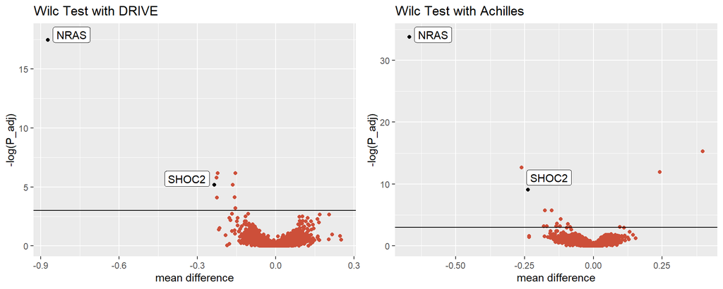

```r
plot.wilc.DRIVE.gene12 <- create_volcano_plot(test.results.gene12,"DRIVE","wilc",
                                       target.genes, show_sign_line=T)

plot.wilc.Achilles.gene12 <- create_volcano_plot(test.results.gene12,"Achilles",
                                                "wilc",target.genes)

grid.arrange(plot.wilc.DRIVE.gene12,plot.wilc.Achilles.gene12,ncol=2)
```

```r
rm(plot.wilc.DRIVE.gene12,plot.wilc.Achilles.gene12)
```

```r
significant.genes.table.DRIVE.gene12 <- create.significant.genes.table(
  test.results.gene12,"DRIVE","wilc")
significant.genes.table.Achilles.gene12 <- create.significant.genes.table(
  test.results.gene12,"Achilles","wilc")

knitr::kable(significant.genes.table.DRIVE.gene12, format = "html",
             table.attr = "style='width:50%;'",
             caption = "Significant Genes in DRIVE")
```

Table 9: Significant Genes in DRIVE

|  | gene | p_value | p_adj | log |
| --- | --- | --- | --- | --- |
| 4194 | NRAS | 0.00e+00 | 0.0000000 | 17.474261 |
| 4513 | GHRL | 5.00e-07 | 0.0021114 | 6.160415 |
| 2184 | ARHGEF18 | 8.00e-07 | 0.0021201 | 6.156271 |
| 2362 | MCM9 | 1.50e-06 | 0.0030402 | 5.795824 |
| 6795 | SHOC2 | 4.00e-06 | 0.0056484 | 5.176391 |
| 6857 | TSSK3 | 4.20e-06 | 0.0056484 | 5.176391 |
| 3535 | ANKRD36 | 1.44e-05 | 0.0164305 | 4.108618 |
| 541 | LOC107984065 | 1.70e-05 | 0.0169285 | 4.078757 |
| 4731 | ING3 | 4.54e-05 | 0.0402617 | 3.212355 |

```r
knitr::kable(significant.genes.table.Achilles.gene12, format = "html",
             table.attr = "style='width:50%;'",
             caption = "Significant Genes in Achilles")
```

Table 9: Significant Genes in Achilles

|  | gene | p_value | p_adj | log |
| --- | --- | --- | --- | --- |
| 10065 | NRAS | 0.00e+00 | 0.0000000 | 33.764759 |
| 6240 | GRB2 | 0.00e+00 | 0.0000002 | 15.287694 |
| 12388 | RAF1 | 0.00e+00 | 0.0000031 | 12.690801 |
| 12166 | PTPN11 | 0.00e+00 | 0.0000067 | 11.911625 |
| 13625 | SHOC2 | 0.00e+00 | 0.0001169 | 9.053978 |
| 6058 | GOLGA7 | 1.20e-06 | 0.0031609 | 5.756905 |
| 9114 | MORF4L1 | 1.30e-06 | 0.0031609 | 5.756905 |
| 2907 | CHCHD3 | 6.00e-06 | 0.0132185 | 4.326141 |
| 5669 | GABPB1 | 1.37e-05 | 0.0269077 | 3.615343 |
| 7088 | IKZF1 | 1.67e-05 | 0.0294338 | 3.525613 |
| 3309 | COLCA2 | 3.11e-05 | 0.0408475 | 3.197910 |
| 8838 | MED24 | 3.17e-05 | 0.0408475 | 3.197910 |
| 9168 | MRGBP | 3.24e-05 | 0.0408475 | 3.197910 |
| 11783 | PPP4C | 2.67e-05 | 0.0408475 | 3.197910 |
| 1279 | BAHD1 | 4.29e-05 | 0.0472954 | 3.051343 |
| 10880 | PARVA | 4.29e-05 | 0.0472954 | 3.051343 |

```r
rm(significant.genes.table.DRIVE.gene12,significant.genes.table.Achilles.gene12)
```

## Bayes Test

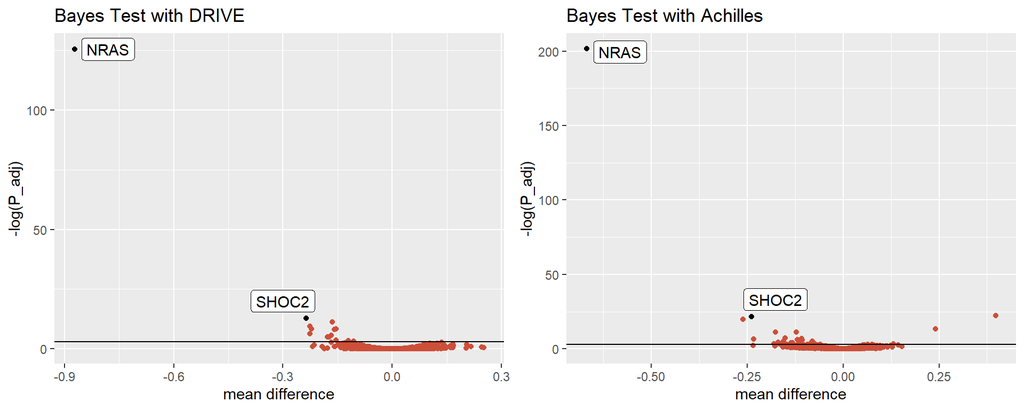

```r
plot.bayes.DRIVE.gene12 <- create_volcano_plot(test.results.gene12,"DRIVE",
                                               "bayes",target.genes)

plot.bayes.Achilles.gene12 <- create_volcano_plot(test.results.gene12,
                                                  "Achilles","bayes",
                                                  target.genes)

grid.arrange(plot.bayes.DRIVE.gene12,plot.bayes.Achilles.gene12,ncol=2)
```

```r
rm(plot.bayes.DRIVE.gene12,plot.bayes.Achilles.gene12)
```

```r
significant.genes.table.DRIVE.gene12 <- create.significant.genes.table(
  test.results.gene12,"DRIVE","bayes")
significant.genes.table.Achilles.gene12 <- create.significant.genes.table(
  test.results.gene12,"Achilles","bayes")

knitr::kable(significant.genes.table.DRIVE.gene12, format = "html",
             table.attr = "style='width:50%;'",
             caption = "Significant Genes in DRIVE")
```

Table 10: Significant Genes in DRIVE

|  | gene | p_adj | log |
| --- | --- | --- | --- |
| 4194 | NRAS | 0.0000000 | 125.427242 |
| 6795 | SHOC2 | 0.0000029 | 12.746940 |
| 6857 | TSSK3 | 0.0000147 | 11.127930 |
| 2362 | MCM9 | 0.0000859 | 9.361909 |
| 2184 | ARHGEF18 | 0.0002287 | 8.383156 |
| 4513 | GHRL | 0.0002287 | 8.383156 |
| 3535 | ANKRD36 | 0.0002956 | 8.126597 |
| 541 | LOC107984065 | 0.0018139 | 6.312264 |
| 5530 | RAF1 | 0.0033609 | 5.695554 |
| 2804 | UTS2R | 0.0064286 | 5.046997 |
| 4319 | SOST | 0.0068349 | 4.985715 |
| 4731 | ING3 | 0.0237142 | 3.741682 |
| 1985 | ANKRD26 | 0.0324463 | 3.428170 |
| 6084 | SPG7 | 0.0398350 | 3.223009 |

```r
knitr::kable(significant.genes.table.Achilles.gene12, format = "html",
             table.attr = "style='width:50%;'",
             caption = "Significant Genes in Achilles")
```

Table 10: Significant Genes in Achilles

|  | gene | p_adj | log |
| --- | --- | --- | --- |
| 10065 | NRAS | 0.0000000 | 201.568058 |
| 6240 | GRB2 | 0.0000000 | 22.316905 |
| 13625 | SHOC2 | 0.0000000 | 21.466882 |
| 12388 | RAF1 | 0.0000000 | 19.845255 |
| 12166 | PTPN11 | 0.0000017 | 13.264172 |
| 3309 | COLCA2 | 0.0000122 | 11.315815 |
| 6058 | GOLGA7 | 0.0000122 | 11.315815 |
| 9114 | MORF4L1 | 0.0007926 | 7.140169 |
| 4150 | DMXL1 | 0.0010785 | 6.832141 |
| 7293 | IRF4 | 0.0015318 | 6.481309 |
| 2907 | CHCHD3 | 0.0018524 | 6.291247 |
| 12558 | RCE1 | 0.0025158 | 5.985163 |
| 3187 | CNBP | 0.0045644 | 5.389479 |
| 6308 | GSS | 0.0052523 | 5.249087 |
| 6503 | HECTD2 | 0.0063393 | 5.060987 |
| 8256 | LIPT1 | 0.0063940 | 5.052390 |
| 9168 | MRGBP | 0.0121296 | 4.412107 |
| 11783 | PPP4C | 0.0174606 | 4.047810 |
| 5669 | GABPB1 | 0.0195888 | 3.932796 |
| 1279 | BAHD1 | 0.0212943 | 3.849314 |
| 8838 | MED24 | 0.0323662 | 3.430641 |
| 12351 | RABGEF1 | 0.0323662 | 3.430641 |
| 1126 | ATP1B3 | 0.0324632 | 3.427650 |
| 1391 | BHMT | 0.0324632 | 3.427650 |
| 9801 | NFKB1 | 0.0324632 | 3.427650 |
| 12704 | RHEB | 0.0324632 | 3.427650 |
| 12581 | REC114 | 0.0373905 | 3.286339 |
| 4643 | EMC6 | 0.0444448 | 3.113507 |
| 13655 | SIK3 | 0.0444448 | 3.113507 |
| 6016 | GNB5 | 0.0451275 | 3.098263 |
| 1416 | BLOC1S3 | 0.0480424 | 3.035672 |
| 13775 | SLC20A1 | 0.0480424 | 3.035672 |
| 3626 | CTRB2 | 0.0495105 | 3.005571 |
| 8855 | MEF2C | 0.0499530 | 2.996672 |

```r
rm(significant.genes.table.DRIVE.gene12,significant.genes.table.Achilles.gene12,
   test.results.gene12)
```